# Assignment 1 - Data wrangling and functions

SAMUEL GARCIA

September 15, 2026 | 12:38:29 | PDT

```r
# LOAD THE PACKAGES YOU ARE USING IN THIS CODE CHUNK
# library(nameofpackage)
library(tidyverse)
```

## Task 1: Getting started with the Astronaut Database

The data this week comes from [Mariya Stavnichuk and Tatsuya Corlett](https://data.mendeley.com/datasets/86tsnnbv2w/1).

This [article](https://www.sciencedirect.com/science/article/abs/pii/S2214552420300444) talks about the data set in greater detail.

> This database contains publically available information about all astronauts who participated in space missions before 15 January 2020 collected from NASA, Roscosmos, and fun-made websites. The provided information includes full astronaut name, sex, date of birth, nationality, military status, a title and year of a selection program, and information about each mission completed by a particular astronaut such as a year, ascend and descend shuttle names, mission and extravehicular activity (EVAs) durations.

You can use the data set directly by importing the csv file in the repository.

1. How many unique astronauts are stored in the data set?

```r
# Answer for #a is 564 unique astronauts. Code used is astronauts <- read.csv("astronauts.csv")
# then enter in n_distinct(astronauts$name)
astronauts <- read.csv("astronauts.csv")
view(astronauts)
names(astronauts)
```

```
 [1] "id"                       "number"
 [3] "nationwide_number"        "name"
 [5] "original_name"            "sex"
 [7] "year_of_birth"            "nationality"
 [9] "military_civilian"        "selection"
[11] "year_of_selection"        "mission_number"
[13] "total_number_of_missions" "occupation"
[15] "year_of_mission"          "mission_title"
[17] "ascend_shuttle"           "in_orbit"
[19] "descend_shuttle"          "hours_mission"
[21] "field21"                  "eva_hrs_mission"
[23] "total_eva_hrs"
```

```r
nrow(astronauts)
```

```
[1] 1277
```

```r
n_distinct(astronauts$name)
```

```
[1] 564
```

2. What’s the overall share of female astronauts? And what’s the share of astronauts with U.S. nationality?

```r
# Answer for #b. unique_astronauts <- distinct(astronauts, name, .keep_all = TRUE)
# mean(unique_astronauts$sex == "female") * 100 = 11.35% are female.
# some have dual citizenship so I included "U.S." and "U.K./U.S." here is my code unique(unique_astronauts$nationality) mean(unique_astronauts$nationality == "U.S." | unique_astronauts$nationality == "U.K./U.S.") * 100 and I got 61.5% U.S. nationality.
unique_astronauts <- distinct(astronauts, name, .keep_all = TRUE)
mean(unique_astronauts$sex == "female") * 100
```

```
[1] 11.34752
```

```r
unique(unique_astronauts$nationality)
```

```
 [1] "U.S.S.R/Russia"           "U.S."
 [3] "Mongolia"                 "Romania"
 [5] "France"                   "Czechoslovakia"
 [7] "Poland"                   "Germany"
 [9] "Bulgaria"                 "Hungry"
[11] "Vietnam"                  "Cuba"
[13] "India"                    "Canada"
[15] "Saudi Arabia"             "Netherland"
[17] "Mexico"                   "Syria"
[19] "Afghanistan"              "Japan"
[21] "U.K."                     "Austria"
[23] "Belgium"                  "Switzerland"
[25] "Italy"                    "Australia"
[27] "U.S.S.R/Ukraine"          "Spain"
[29] "Slovakia"                 "Republic of South Africa"
[31] "U.K./U.S."                "Israel"
[33] "China"                    "Brazil"
[35] "Sweden"                   "Malysia"
[37] "Korea"                    "Denmark"
[39] "Kazakhstan"               "UAE"
```

```r
mean(unique_astronauts$nationality == "U.S.") * 100
```

```
[1] 60.99291
```

```r
mean(grepl("U.S.", unique_astronauts$nationality)) * 100
```

```
[1] 83.33333
```

```r
mean(unique_astronauts$nationality == "U.S." | unique_astronauts$nationality == "U.K./U.S.") * 100
```

```
[1] 61.52482
```

3. Create a new data set `total_hours_df` containing the unique names and the total duration of all missions in hours (`total_hrs_sum`) for each astronaut in the data. Then, visualize the distribution of that variable using an appropriate plot type.

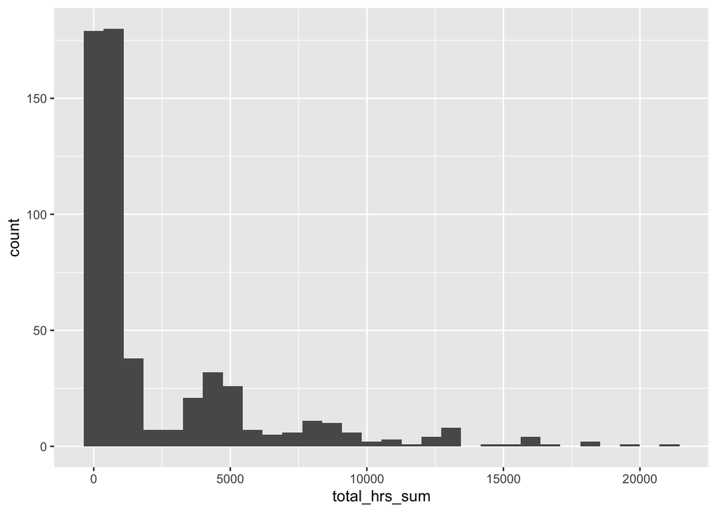

```r
# Answer for #c, total_hours_df <- astronauts |> group_by(name) |> summarise(total_hrs_sum = sum(hours_mission, na.rm = TRUE))
#checked it with view(total_hours_df) add ggplot for histogram so, ggplot(total_hours_df, aes(x = total_hrs_sum)) + geom_histogram()
total_hours_df <- astronauts |> group_by(name) |> summarise(total_hrs_sum = sum(hours_mission, na.rm = TRUE))
ggplot(total_hours_df, aes(x = total_hrs_sum)) + geom_histogram()
```

4. Provide a plot that shows the overall share of *civilian* astronauts by the year of mission!

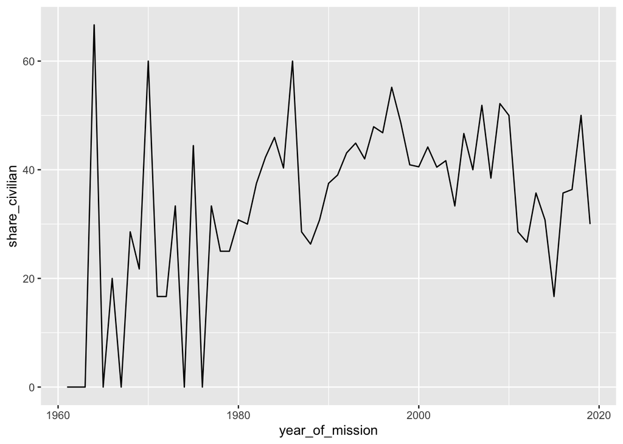

```r
# YOUR CODE HERE
civilian_share <- astronauts |> group_by(year_of_mission) |> summarise(share_civilian = mean(military_civilian == "civilian") * 100)
ggplot(civilian_share, aes(x = year_of_mission, y = share_civilian)) + geom_line()
```

### Task 2 – Writing functions

1. Given a vector of birthdates, write a function that computes the vector of corresponding ages in years.

```r
# Answer#a I will choose c(1988,1989,1990,1991,1992) as my vector
# gonna call it age_years and make the function be birth_year - 2026
c(1988,1989,1990,1991,1992)
```

```
[1] 1988 1989 1990 1991 1992
```

```r
age_years <- function(birth_year) {2026 - birth_year}
age_years(c(1988, 1989, 1991, 1992))
```

```
[1] 38 37 35 34
```

2. Write `both_na()`, a summary function that takes two vectors of the same length and returns the number of positions that have an `NA` in both vectors. For example the two vectors `a <- c(1, NA, 2, NA)` and `b <- c(3, NA, NA, 4)` should give 1.

```r
# YOUR CODE HERE
#okay so our two vectors are
#    a <- c(1, NA, 2, NA)
#AND b <- c(3, NA, NA, 4)
#position 1-has numbers not both NA, position 2 is YES has both NA, position 3 is NO has mix, position 4 NO is mix as well
both_na <- function(x, y) {sum(is.na(x) & is.na(y))}
a <- c(1, NA, 2, NA)
b <- c(3, NA, NA, 4)
both_na(a, b)
```

```
[1] 1
```

3. Program a function `check_password(pw)` that takes a password string `pw` and returns a funny *strength rating* according to the following rules:
1. If the password contains the word `"password"` (in any mix of upper/lower case), return `"Terrible!"`.
2. If the password is shorter than 6 characters, return `"Too weak"`.
3. If it contains only letters, return `"Meh"`.
4. If it contains letters **and** numbers, return `"Not bad"`.
5. If it contains letters **and** numbers **and** at least one special character from `!@#$%^&*?`, return `"Strong"`.

Write the function and test it with at least **five different passwords** that trigger different outputs. Also, use functions from the `stringr` package to execute the checks in your function (hint: look up `str_detect()` and `str_length()`).

```r
# YOUR CODE HERE
#okay so we are creating passwords and seeing if they pass the mark according to each function(?)
# create at least 5 that match the req. for each function
check_password <- function(pw) ifelse(str_detect(str_to_lower(pw), "password"), "Terrible!", ifelse(str_length(pw) <6, "Too weak", ifelse(str_detect(pw, "^[A-Za-z]+$"), "Meh", ifelse(str_detect(pw, "[A-Za-z]") & str_detect(pw, "[0-9]"), "Not bad", ifelse(str_detect(pw, "[A-Za-z]") & str_detect(pw, "[0-9]") & str_detect(pw, "[!@#$%^&*?]"), "Strong", NA)))))
check_password("Password123")
```

```
[1] "Terrible!"
```

```r
check_password("abc")
```

```
[1] "Too weak"
```

```r
check_password("abcdef")
```

```
[1] "Meh"
```

```r
check_password("abc123")
```

```
[1] "Not bad"
```

```r
check_password("Abcd123#%#4ABC")
```

```
[1] "Not bad"
```

```r
#i give up on the last one, whyyyyyy :*( LOL.
```

### Bonus challenge - The Monty Hall Machine

**Note: This task is optional and not required for the assignment.**

1. Write an R function that simulates the [Monty Hall problem](https://en.wikipedia.org/wiki/Monty_Hall_problem). Start with writing a function called `monty_hall_choice()` that:
- Simulates a single round of the Monty Hall problem.
- Has an argument `switch` that controls whether the contestant switches doors after Monty reveals a goat.
- Returns `TRUE` if the contestant wins the car, and `FALSE` if they do not. Test it by running it 10 times each with `switch = TRUE` and `switch = FALSE`, and summarize the results. *HINT: Consider loops*.

```r
# YOUR CODE HERE
```

2. Now, create a function `monty_hall_simulation()` to simulate multiple rounds of the Monty Hall problem:
- The function should wrap around the `monty_hall_choice()`.
- Add an argument `n` to the function that specifies how many rounds to simulate.
- The function should return the proportion of times the contestant wins the car for both strategies (`switch = TRUE` and `switch = FALSE`).

```r
# YOUR CODE HERE
```

3. Generalize the Monty Hall Problem to $k$ doors and $k-1$ goats, where the host will open all doors except for 2. Now, visualize the probability of winning (proportion of wins) for both strategies (switch and stay) as a function of the number of simulated rounds n and the number of doors $k$, for a set of values for both $n$ and $k$ that you choose. *Important:* This is just for fun. You don’t have to work on this task if you don’t have time. Providing a right/wrong solution does not give/cost you extra points. (A right solution gives you kudos from the instructor though!)

```r
# YOUR CODE HERE
```